# Bioestadística Fundamental

Departamento de Estadística, Sede Bogotá

## Clase 25

Ajuste de Modelos de Regresión

## Contenido

### Parte I: Modelos de regresión lineal

- Motivación: variables cuantitativas vs. ANOVA.
- Forma general del modelo y supuestos.
- Ejemplo agrícola central: rendimiento de caña de azúcar.
- Estimación por mínimos cuadrados.

### Parte II: Pruebas de hipótesis

- Significancia global de la regresión y tabla ANOVA.
- Pruebas t individuales y F parcial por subconjuntos.

### Parte III: Intervalos y predicción

- IC para coeficientes y para la respuesta media.
- Intervalo de predicción para una observación nueva.

### Parte IV: Diagnóstico del modelo

- Residuos escalados y estadístico PRESS.
- Leverage, distancia de Cook, DFFITS.
- Prueba de falta de ajuste.

Modelos de Regresión Lineal Múltiple

¿Cómo modelar una respuesta cuantitativa en función de variables explicativas también cuantitativas?

## Motivación: de los factores a las variables continuas

En el ANOVA se comparan medias de una respuesta entre niveles de un **factor cualitativo** (tipo de fertilizante, variedad, método). Pero muchas variables agronómicas relevantes son **cuantitativas continuas**: precipitación, dosis de nitrógeno, horas de sol, altitud.

ANOVA

Compara medias entre **grupos o niveles** de una variable cualitativa (factor).

Regresión

Modela la **relación funcional** entre la respuesta y una o más variables explicativas continuas.

Por ejemplo: en lugar de comparar el rendimiento de caña de azúcar entre tres niveles fijos de nitrógeno, la regresión permite estimar cómo cambia el rendimiento **para cualquier dosis** de nitrógeno aplicada.

## Ejemplo agrícola central: caña de azúcar en el Valle del Cauca

Un ingeniero agrónomo del Valle del Cauca desea modelar el **rendimiento de caña de azúcar** (ton/ha) en función de tres variables continuas registradas en 28 lotes de cultivo durante un ciclo productivo:

**$x_1$: Precipitación**  
mm/mes promedio

**$x_2$: Nitrógeno**  
dosis aplicada (kg/ha)

**$x_3$: Horas de sol**  
promedio diario (h)

$y$: Rendimiento de caña de azúcar (ton/ha). Este dataset de $n=28$ lotes se usará a lo largo de toda la clase.

## Datos del ejemplo: rendimiento de caña de azúcar

Primeras observaciones del conjunto de datos ($n=28$ lotes):

| Lote | Precip. (mm) | N (kg/ha) | Sol (h) | Rend. (ton/ha) |
| --- | --- | --- | --- | --- |
| 1 | 185.2 | 200.0 | 5.23 | 88.1 |
| 2 | 151.8 | 116.3 | 6.07 | 78.8 |
| 3 | 156.8 | 139.2 | 6.68 | 78.9 |
| 4 | 154.8 | 100.1 | 6.10 | 83.9 |
| 5 | 191.4 | 147.1 | 4.53 | 80.7 |
| … | … | … | … | … |
| 27 | 191.1 | 152.8 | 7.25 | 100.5 |
| 28 | 115.9 | 130.2 | 4.30 | 70.4 |

Medias: $\bar x_1=159.1$ mm, $\bar x_2=151.4$ kg/ha, $\bar x_3=5.81$ h, $\bar y=84.36$ ton/ha.

## Dispersión de los datos: rendimiento contra cada covariable

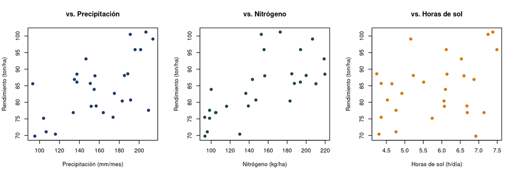

Las tres variables muestran una relación positiva con el rendimiento: sugiere que un modelo lineal múltiple es razonable.

## Forma general del modelo de regresión lineal

El modelo de regresión lineal múltiple relaciona una respuesta $y$ con $k$ variables explicativas $x_1,\ldots,x_k$:

Modelo de regresión lineal múltiple

$$y=\beta_0+\beta_1 x_1+\beta_2 x_2+\cdots+\beta_k x_k+\varepsilon$$

- $\beta_0$: intercepto, valor esperado de $y$ cuando todas las $x_i=0$.
- $\beta_j$: efecto marginal de $x_j$ sobre $y$, manteniendo constantes las demás variables.
- $\varepsilon$: error aleatorio no explicado por el modelo.
- $k=3$ en el ejemplo: precipitación, nitrógeno y horas de sol.

## Supuestos del modelo de regresión lineal

**Linealidad**  
La relación entre $y$ y las $x_j$ es lineal en los parámetros.

**Normalidad**  
$\varepsilon\sim N(0,\sigma^2)$

**Homocedasticidad**  
Varianza $\sigma^2$ constante para todos los niveles de $x$

**Independencia**  
Los errores $\varepsilon_i$ son independientes entre observaciones.

**No colinealidad perfecta**  
Las variables $x_j$ no son combinaciones lineales exactas entre sí.

Estos supuestos se verifican mediante el análisis de residuos (Parte IV de esta clase).

## Estimación de los parámetros: idea de mínimos cuadrados

El método de **mínimos cuadrados ordinarios** (MCO) busca los valores $\hat\beta_0,\hat\beta_1,\ldots,\hat\beta_k$ que minimizan la suma de cuadrados de los residuos:

Criterio de mínimos cuadrados

$$SC_E=\sum_{i=1}^n \left(y_i-\hat\beta_0-\sum_{j=1}^k \hat\beta_j x_{ij}\right)^2$$

Geométricamente: se busca el hiperplano que minimiza la suma de las distancias verticales al cuadrado entre los puntos observados y los valores ajustados.

## Estimación matricial de los parámetros

En notación matricial, el modelo se escribe $\mathbf{y}=\mathbf{X}\boldsymbol\beta+\boldsymbol\varepsilon$, donde $\mathbf{X}$ es la matriz de diseño ($n\times(k+1)$, con una columna de unos para el intercepto).

Estimador de mínimos cuadrados

$$\hat{\boldsymbol\beta}=(\mathbf{X}'\mathbf{X})^{-1}\mathbf{X}'\mathbf{y}$$

- $\mathbf{X}'\mathbf{X}$: matriz de sumas de cuadrados y productos cruzados de las covariables.
- $(\mathbf{X}'\mathbf{X})^{-1}$: existe siempre que las columnas de $\mathbf{X}$ sean linealmente independientes (no colinealidad perfecta).
- Este estimador es el mismo que minimiza $SC_E$; ambos enfoques (cálculo diferencial y álgebra matricial) llevan a la misma solución.

## Estimaciones del modelo: caña de azúcar

Aplicando $\hat{\boldsymbol\beta}=(\mathbf{X}'\mathbf{X})^{-1}\mathbf{X}'\mathbf{y}$ a los datos de los 28 lotes se obtiene el siguiente modelo ajustado:

| Parámetro | Estimación $\hat\beta_j$ | Error estándar |
| --- | --- | --- |
| $\beta_0$ (Intercepto) | 32.585 | 6.474 |
| $\beta_1$ (Precipitación) | 0.1092 | 0.0251 |
| $\beta_2$ (Nitrógeno) | 0.1241 | 0.0207 |
| $\beta_3$ (Horas de sol) | 2.6894 | 0.8199 |

$$\hat y = 32.585+0.109\,x_1+0.124\,x_2+2.689\,x_3$$

## Interpretación de los coeficientes estimados

Cada coeficiente representa el efecto marginal de su variable, manteniendo las demás constantes (*ceteris paribus*):

Por cada mm/mes adicional de precipitación, el rendimiento aumenta en promedio **0.109 ton/ha**, fijando nitrógeno y horas de sol.

Por cada kg/ha adicional de nitrógeno, el rendimiento aumenta en promedio **0.124 ton/ha**, fijando precipitación y sol.

Por cada hora adicional de sol diario, el rendimiento aumenta en promedio **2.689 ton/ha**, fijando precipitación y nitrógeno.

El intercepto ($32.585$) no tiene interpretación agronómica directa, pues ninguna de las covariables se acerca a cero en la práctica.

## Recta de regresión ajustada: valores observados versus ajustados

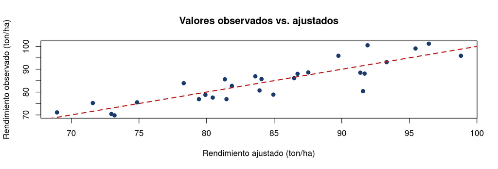

Los puntos se concentran alrededor de la línea de identidad ($y=\hat y$), indicando un buen ajuste global. $R^2=0.775$: el modelo explica el 77.5% de la variabilidad del rendimiento.

## Errores comunes: fundamentos de regresión

Advertencia: errores frecuentes

- Interpretar $\beta_0$ fuera del rango observado de las covariables (extrapolación sin sentido agronómico).
- Confundir “efecto marginal manteniendo las demás constantes” con el efecto total observado en los datos crudos.
- Ajustar un modelo lineal sin verificar gráficamente que la relación entre $y$ y cada $x_j$ sea aproximadamente lineal.
- Ignorar la posible colinealidad entre covariables (ej. precipitación y horas de sol suelen estar correlacionadas negativamente).

Pruebas de Hipótesis en Regresión Múltiple

¿El modelo en conjunto explica la variabilidad de la respuesta? ¿Cada variable individual aporta significativamente?

## Prueba de significancia de la regresión

Antes de interpretar coeficientes individuales, se evalúa si el modelo, en su conjunto, explica una proporción significativa de la variabilidad de $y$.

Hipótesis de significancia global

$$H_0:\beta_1=\beta_2=\cdots=\beta_k=0 \qquad \text{vs.} \qquad H_1: \text{algún } \beta_j\neq 0$$

$H_0$ implica que ninguna de las variables explicativas tiene relación lineal con $y$: el “mejor predictor” sería simplemente $\bar y$.

## Descomposición de la suma de cuadrados en regresión

Identidad de la suma de cuadrados

$$\underbrace{\sum_{i=1}^n(y_i-\bar y)^2}_{SC_T}
=
\underbrace{\sum_{i=1}^n(\hat y_i-\bar y)^2}_{SC_{Reg}}
+
\underbrace{\sum_{i=1}^n(y_i-\hat y_i)^2}_{SC_E}$$

$SC_{Reg}$: variabilidad explicada por las variables $x_1,\ldots,x_k$.

$SC_E$: variabilidad residual, no explicada por el modelo.

## Tabla ANOVA de regresión y estadístico F

Cada suma de cuadrados se divide por sus grados de libertad. El estadístico de prueba es el cociente de cuadrados medios:

| Fuente | SC | gl | CM | F |  |
| --- | --- | --- | --- | --- | --- |
| Regresión | $SC_{Reg}$ | $k$ | $CM_{Reg}=\frac{SC_{Reg}}{k}$ | $F=\dfrac{CM_{Reg}}{CM_E}$ |  |
| Error | $SC_E$ | $n-k-1$ | $CM_E=\frac{SC_E}{n-k-1}$ |  |  |
| Total | $SC_T$ | $n-1$ |  |  |  |

Bajo $H_0$, $F=\dfrac{CM_{Reg}}{CM_E}\sim F_{k,\,n-k-1}$. Se rechaza $H_0$ si $F_{calc}>F_{\alpha,\,k,\,n-k-1}$.

## Resultado del ejemplo: tabla ANOVA de la caña de azúcar

| Fuente | SC | gl | CM | F | valor-p |  |  |
| --- | --- | --- | --- | --- | --- | --- | --- |
| Regresión | 1685.91 | 3 | 561.97 | 27.63 | $5.90\times10^{-8}$ |  |  |
| Error | 488.23 | 24 | 20.34 |  |  |  |  |
| Total | 2174.14 | 27 |  |  |  |  |  |

$CM_{Reg}=1685.91/3=561.97$, $CM_E=488.23/24=20.34$, $F=561.97/20.34=27.63$.

## Criterio de decisión y conclusión: significancia global

Criterio de decisión

$$F_{calc}=27.63 > F_{0.05,3,24}=3.01$$
$$\text{valor-p}=5.90\times10^{-8}<0.05$$
Se rechaza $H_0$.

Conclusión

Existe evidencia estadística suficiente para afirmar que al menos una de las variables (precipitación, nitrógeno, horas de sol) tiene efecto sobre el rendimiento de la caña de azúcar.

$R^2=SC_{Reg}/SC_T=1685.91/2174.14=0.7754$: el modelo explica el 77.5% de la variabilidad del rendimiento.

## Pruebas t para coeficientes individuales

Una vez confirmada la significancia global, se evalúa si **cada coeficiente** $\beta_j$ aporta significativamente al modelo, controlando por las demás variables.

Prueba t individual

$$H_0:\beta_j=0 \quad \text{vs.} \quad H_1:\beta_j\neq 0
\qquad
t=\frac{\hat\beta_j}{EE(\hat\beta_j)}\sim t_{n-k-1}$$

Se rechaza $H_0$ si $|t_{calc}|>t_{\alpha/2,\,n-k-1}$. Esta prueba evalúa el aporte **marginal** de $x_j$, no su efecto en un modelo simple sin las demás variables.

## Resultado del ejemplo: pruebas t individuales

| Variable | $\hat\beta_j$ | $EE(\hat\beta_j)$ | $t_{calc}$ | valor-p |
| --- | --- | --- | --- | --- |
| Intercepto | 32.585 | 6.474 | 5.033 | $3.82\times10^{-5}$ |
| Precipitación | 0.109 | 0.025 | 4.342 | 0.00022 |
| Nitrógeno | 0.124 | 0.021 | 5.987 | $3.52\times10^{-6}$ |
| Horas de sol | 2.689 | 0.820 | 3.280 | 0.00316 |

Con $gl=n-k-1=24$ y $t_{0.025,24}=2.064$: las tres variables presentan $|t_{calc}|>2.064$, por lo que **todas son significativas** al 5%, controlando por las demás.

## Prueba F parcial: subconjuntos de coeficientes

La prueba F parcial compara un **modelo completo** contra un **modelo reducido** (sin un subconjunto de variables), para evaluar si esas variables aportan significativamente en conjunto.

Estadístico F parcial

$$F=\frac{(SC_{E,red}-SC_{E,comp})/r}{CM_{E,comp}}\sim F_{r,\,n-k-1}$$

- $SC_{E,red}$: suma de cuadrados del error del modelo reducido.
- $SC_{E,comp}$: suma de cuadrados del error del modelo completo.
- $r$: número de coeficientes eliminados al pasar del modelo completo al reducido.

## Ejemplo: ¿es significativo el efecto de horas de sol?

Pregunta: controlando por precipitación y nitrógeno, ¿aporta significativamente la variable horas de sol? Se comparan:

**Modelo reducido**  
$y=\beta_0+\beta_1 x_1+\beta_2 x_2+\varepsilon$  
$SC_{E,red}=707.11$, $gl=25$

**Modelo completo**  
$y=\beta_0+\beta_1 x_1+\beta_2 x_2+\beta_3 x_3+\varepsilon$  
$SC_{E,comp}=488.23$, $gl=24$

$$F=\frac{(707.11-488.23)/1}{20.34}=\frac{218.88}{20.34}=10.76$$

$F_{0.05,1,24}=4.26$. Como $10.76>4.26$ (y valor-p $=0.00316$), se rechaza $H_0:\beta_3=0$: las horas de sol aportan significativamente, incluso controlando por las otras dos variables.

## Relación entre prueba t y prueba F parcial

Cuando se elimina **una sola variable** ($r=1$), la prueba F parcial es equivalente a la prueba t individual: $F=t^2$.

Verificación: $t_{calc}=3.280$ para horas de sol, y $t^2=3.280^2=10.76=F_{calc}$. Coinciden exactamente.

La prueba F parcial es más general: permite evaluar **varios coeficientes simultáneamente** ($r>1$), algo que la prueba t individual no puede hacer.

## Errores comunes: pruebas de hipótesis en regresión

Advertencia: errores frecuentes

- Concluir, a partir de la prueba F global significativa, que **todas** las variables son individualmente significativas (puede que solo algunas lo sean).
- Eliminar variables del modelo basándose únicamente en su valor-p individual, sin considerar el contexto agronómico ni posibles colinealidades.
- Comparar modelos con prueba F parcial cuando no están **anidados** (el modelo reducido debe ser un caso particular del completo).
- Olvidar que un coeficiente no significativo no implica ausencia de relación, sino ausencia de aporte marginal dado el resto del modelo.

Intervalos de Confianza y Predicción

¿Cuál es el rango plausible para un coeficiente, para la respuesta media, o para una nueva observación?

## Intervalos de confianza para coeficientes individuales

Un intervalo de confianza para $\beta_j$ cuantifica la incertidumbre de la estimación puntual $\hat\beta_j$.

IC para $\beta_j$

$$\hat\beta_j \pm t_{\alpha/2,\,n-k-1}\;EE(\hat\beta_j)$$

Ejemplo: IC 95% para $\beta_2$ (nitrógeno): $0.124\pm 2.064(0.0207)=0.124\pm0.0428$
$$IC_{95\%}(\beta_2)=(0.0813,\;0.1669)$$

## Resultado del ejemplo: IC para los tres coeficientes

| Variable | $\hat\beta_j$ | IC 95% inferior | IC 95% superior |
| --- | --- | --- | --- |
| Intercepto | 32.585 | 19.223 | 45.946 |
| Precipitación | 0.109 | 0.057 | 0.161 |
| Nitrógeno | 0.124 | 0.081 | 0.167 |
| Horas de sol | 2.689 | 0.997 | 4.382 |

Como ninguno de los tres intervalos contiene el cero, se confirma que las tres variables son significativas al 5% (consistente con las pruebas t individuales).

## Intervalo de confianza para la respuesta media

A menudo interesa estimar el rendimiento **esperado** (promedio) para una combinación específica de valores de las covariables $\mathbf{x}_0$, no una observación individual.

IC para la respuesta media

$$\hat y_0 \pm t_{\alpha/2,\,n-k-1}\sqrt{CM_E\,\mathbf{x}_0'(\mathbf{X}'\mathbf{X})^{-1}\mathbf{x}_0}$$

El término bajo la raíz mide la precisión de la estimación, que depende de $CM_E$ y de la posición de $\mathbf{x}_0$ respecto a los datos observados.

## Ejemplo: predicción del rendimiento esperado

Se desea estimar el rendimiento **promedio** de caña de azúcar para condiciones típicas: precipitación $=155$ mm/mes, nitrógeno $=150$ kg/ha y horas de sol $=5.75$ h/día (valores cercanos a las medias del estudio).

$$\hat y_0=32.585+0.109(155)+0.124(150)+2.689(5.75)=83.59 \text{ ton/ha}$$

$$IC_{95\%}(\text{media})=(81.81,\;85.36) \text{ ton/ha}$$

Se estima con 95% de confianza que el rendimiento **promedio** de los lotes con estas condiciones está entre 81.8 y 85.4 ton/ha.

## Predicción de una nueva observación individual

Es distinto predecir el rendimiento **promedio** que predecir el rendimiento de **un lote particular** nuevo. La segunda incluye, además, la variabilidad propia de una observación individual.

Intervalo de predicción

$$\hat y_0 \pm t_{\alpha/2,\,n-k-1}\sqrt{CM_E\left(1+\mathbf{x}_0'(\mathbf{X}'\mathbf{X})^{-1}\mathbf{x}_0\right)}$$

El “$+1$” adicional bajo la raíz hace que el intervalo de predicción sea **siempre más ancho** que el de confianza para la media.

## Comparación numérica: IC de la media versus intervalo de predicción

Para el mismo punto ($x_1=155$, $x_2=150$, $x_3=5.75$), con $\hat y_0=83.59$ ton/ha:

| Tipo de intervalo | Límite inferior | Límite superior | Ancho |
| --- | --- | --- | --- |
| Confianza para la media | 81.81 | 85.36 | 3.55 |
| Predicción individual | 74.11 | 93.06 | 18.95 |

El intervalo de predicción es más de 5 veces más ancho: refleja la incertidumbre adicional de una observación individual frente a un promedio.

Uso práctico: si el agrónomo quiere planificar la producción esperada de la región (promedio), usa el IC de la media; si quiere anticipar el resultado de un lote nuevo específico, usa el intervalo de predicción.

## Errores comunes: intervalos de confianza y predicción

Advertencia: errores frecuentes

- Usar el intervalo de confianza para la media cuando el objetivo es predecir una observación individual (subestima la incertidumbre real).
- Construir intervalos para combinaciones de covariables muy alejadas del rango observado (extrapolación), donde el modelo pierde validez.
- Interpretar el ancho del intervalo de predicción como un error en el modelo, cuando en realidad refleja la variabilidad natural entre lotes.

Diagnóstico del Modelo de Regresión

¿El modelo ajustado es confiable? ¿Existen observaciones que distorsionan los resultados?

## Residuos escalados: estandarizados y estudentizados

Los residuos crudos $e_i=y_i-\hat y_i$ no son directamente comparables entre sí, pues su varianza depende de la posición de cada observación. Por ello se escalan.

**Residuo estandarizado**
$$r_i=\frac{e_i}{\sqrt{CM_E(1-h_{ii})}}$$

**Residuo estudentizado** (eliminado)
$$t_i=\frac{e_i}{\sqrt{CM_{E(i)}(1-h_{ii})}}$$

$h_{ii}$ es el leverage de la observación $i$. El residuo estudentizado usa $CM_{E(i)}$, calculado **sin** la observación $i$, por lo que es más sensible para detectar valores atípicos.

## Residuos escalados: resultado del ejemplo

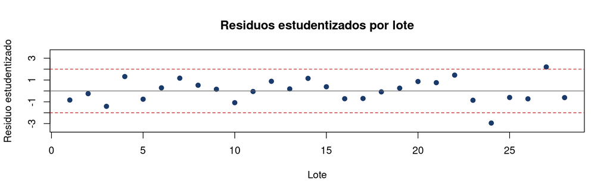

El lote 24 presenta el residuo estudentizado más extremo ($t_{24}=-2.95$), superando el umbral usual de $\pm2$; merece revisión adicional.

## Estadístico PRESS

El estadístico **PRESS** (*Prediction Sum of Squares*) mide la capacidad predictiva del modelo, usando residuos eliminados (*leave-one-out*): cada observación se predice con un modelo ajustado sin ella.

Estadístico PRESS

$$PRESS=\sum_{i=1}^n \left(\frac{e_i}{1-h_{ii}}\right)^2$$

Resultado del ejemplo: $PRESS=639.61$. Como $SC_T=2174.14$:
$$R^2_{pred}=1-\frac{PRESS}{SC_T}=1-\frac{639.61}{2174.14}=0.706$$

$R^2_{pred}=0.706$ es razonablemente cercano a $R^2=0.775$: el modelo predice de forma consistente en datos no usados para su ajuste.

## Diagnósticos de influencia: leverage

El **leverage** ($h_{ii}$, elementos diagonales de la matriz $\mathbf{H}=\mathbf{X}(\mathbf{X}'\mathbf{X})^{-1}\mathbf{X}'$) mide cuán alejada está una observación en el **espacio de las covariables** ($x$), independientemente de su valor de $y$.

Regla práctica de leverage alto

$$h_{ii}>\frac{2(k+1)}{n}$$

En el ejemplo: $k=3$, $n=28$, umbral $=2(4)/28=0.286$. El promedio de los $h_{ii}$ siempre es $(k+1)/n=0.143$.

## Resultado del ejemplo: leverage por lote

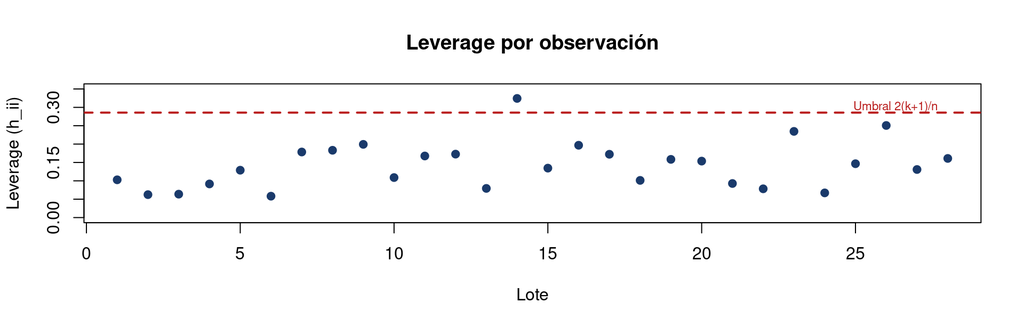

El lote 14 tiene leverage $h_{14}=0.324>0.286$: presenta una combinación inusual de precipitación, nitrógeno y horas de sol respecto a los demás lotes.

## Distancia de Cook

La **distancia de Cook** combina el leverage con la magnitud del residuo: mide cuánto cambiarían las estimaciones $\hat{\boldsymbol\beta}$ si se eliminara la observación $i$.

Distancia de Cook

$$D_i=\frac{r_i^2}{k+1}\cdot\frac{h_{ii}}{1-h_{ii}}$$

Regla práctica usual: observaciones con $D_i>4/n$ se consideran potencialmente influyentes (en el ejemplo, umbral $=4/28=0.143$).

## Resultado del ejemplo: distancia de Cook

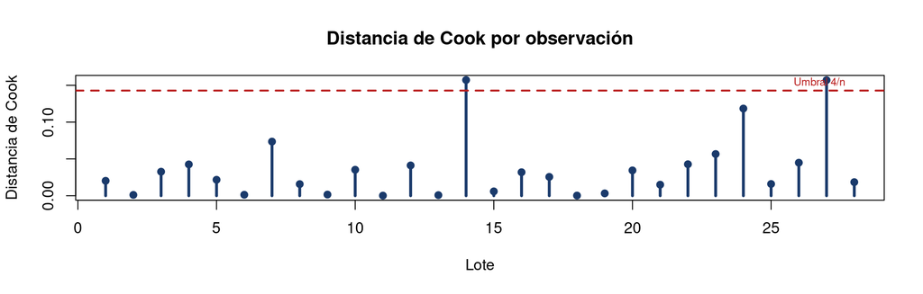

Los lotes 14 ($D_{14}=0.157$) y 27 ($D_{27}=0.157$) superan el umbral $4/n=0.143$: ambos son observaciones potencialmente influyentes, aunque por razones distintas (leverage alto en el lote 14, residuo grande en el lote 27).

## DFFITS y DFBETAS

Mientras la distancia de Cook resume la influencia en **todos** los coeficientes a la vez, DFFITS y DFBETAS detallan la influencia sobre el valor ajustado y sobre cada coeficiente individual, respectivamente.

**DFFITS**: cambio estandarizado en $\hat y_i$ al eliminar la observación $i$.
$$\text{Umbral: }|DFFITS_i|>2\sqrt{(k+1)/n}$$

**DFBETAS**: cambio estandarizado en cada $\hat\beta_j$ al eliminar la observación $i$.
$$\text{Umbral: }|DFBETAS_{ij}|>2/\sqrt{n}$$

En el ejemplo, $2\sqrt{4/28}=0.756$. El lote 14 tiene $DFFITS_{14}=0.798>0.756$: confirma su influencia sobre el valor ajustado, consistente con su alta distancia de Cook.

## Identificación de observaciones influyentes: síntesis

[output not shown]

El lote 14 (alto leverage en nitrógeno: 210.3 kg/ha, casi el máximo del estudio) y el lote 27 (rendimiento inusualmente alto, 100.5 ton/ha) requieren verificación de campo antes de decidir si se excluyen o se mantienen en el análisis.

## Prueba de falta de ajuste: motivación

Cuando existen **réplicas** (observaciones con los mismos valores, o casi idénticos, de las covariables), es posible separar el error total en dos componentes: el **error puro** (variabilidad entre réplicas) y el **error por falta de ajuste** (desviación sistemática del modelo).

Ejemplo conceptual: si en tres lotes distintos se aplicó exactamente la misma dosis de nitrógeno (150 kg/ha) bajo condiciones similares de precipitación y sol, la variación del rendimiento entre esos tres lotes es **error puro**, no atribuible al modelo.

## Tabla ANOVA con descomposición de falta de ajuste

Cuando hay réplicas, $SC_E$ se descompone en error puro ($SC_{EP}$) y falta de ajuste ($SC_{FA}$):

| Fuente | SC | gl | CM | F |  |
| --- | --- | --- | --- | --- | --- |
| Regresión | $SC_{Reg}$ | $k$ | $CM_{Reg}$ |  |  |
| Falta de ajuste | $SC_{FA}$ | $m-k-1$ | $CM_{FA}$ | $F=\dfrac{CM_{FA}}{CM_{EP}}$ |  |
| Error puro | $SC_{EP}$ | $n-m$ | $CM_{EP}$ |  |  |
| Total | $SC_T$ | $n-1$ |  |  |  |

$m$: número de combinaciones distintas de niveles de las covariables.

Se rechaza el supuesto de adecuación del modelo si $F_{calc}=CM_{FA}/CM_{EP}>F_{\alpha,\,m-k-1,\,n-m}$: el modelo lineal no captura toda la estructura sistemática.

## Ejemplo conceptual: falta de ajuste en el cultivo de caña

Supóngase que, en un estudio complementario, se registran tres lotes adicionales con exactamente la misma combinación de precipitación (160 mm/mes), nitrógeno (150 kg/ha) y sol (6.0 h/día), obteniendo rendimientos de 84.1, 85.6 y 83.2 ton/ha.

La variabilidad entre estas tres réplicas (84.1, 85.6, 83.2) es **error puro**: refleja variación natural del suelo o el clima, no del modelo.

Si el promedio ajustado por el modelo para ese punto difiere sistemáticamente del promedio de las réplicas (84.3), esa diferencia indica **falta de ajuste**: el modelo lineal podría no ser adecuado (faltan términos cuadráticos o interacciones).

En la práctica agronómica, las réplicas suelen obtenerse mediante diseños experimentales planeados, no observacionales como el de este ejemplo.

## Errores comunes: diagnóstico del modelo

Advertencia: errores frecuentes

- Eliminar automáticamente toda observación con alta distancia de Cook sin verificar primero si es un error de registro o una observación válida.
- Confundir leverage alto (posición inusual en $x$) con residuo grande (mal ajuste en $y$): son diagnósticos distintos y complementarios.
- Calcular PRESS o residuos estudentizados sin re-ajustar correctamente el modelo “leave-one-out” (las fórmulas exactas evitan recalcular $n$ regresiones).
- Aplicar la prueba de falta de ajuste sin verificar que existan verdaderas réplicas en los niveles de las covariables.

## Taller en Clase

## Instrucciones

Resuelva los siguientes ejercicios aplicando los conceptos de regresión lineal múltiple desarrollados en esta clase: estimación de parámetros, pruebas de hipótesis, intervalos de confianza y predicción, y diagnóstico del modelo.

Para cada ejercicio: plantee las hipótesis, calcule el estadístico correspondiente, aplique el criterio de decisión y concluya en el contexto del problema agrícola.

## Ejercicio 1

Un agrónomo del Tolima ajusta un modelo de regresión múltiple para el rendimiento de arroz (ton/ha) en función de la dosis de fósforo ($x_1$, kg/ha) y la densidad de siembra ($x_2$, plantas/m²), con $n=20$ parcelas. Obtiene:
$$\hat y=2.1+0.045x_1+0.38x_2 \qquad EE(\hat\beta_1)=0.014 \qquad EE(\hat\beta_2)=0.11$$

1. Realice la prueba t para cada coeficiente con $\alpha=0.05$ y concluya.
2. Construya el IC 95% para $\beta_1$.
3. Interprete $\hat\beta_2$ en el contexto agronómico.

## Ejercicio 2

Para un modelo de rendimiento de papa (ton/ha) en función de altitud (msnm), precipitación (mm) y dosis de potasio (kg/ha), con $n=24$, se obtiene la tabla ANOVA:

| Fuente | SC | gl |
| --- | --- | --- |
| Regresión | 845.2 | 3 |
| Error | 312.6 | 20 |

1. Complete la tabla ANOVA (CM, F).
2. Realice la prueba de significancia global con $\alpha=0.05$.
3. Calcule $R^2$ e interprete.

## Ejercicio 3

Una asociación de ganaderos del Casanare modela la ganancia de peso de novillos (kg/mes) en función de la carga animal (UA/ha), la oferta forrajera (kg MS/ha) y la suplementación mineral (g/animal/día). El modelo completo tiene $SC_E=145.3$ con $gl=26$; el modelo sin la variable suplementación mineral tiene $SC_E=189.7$ con $gl=27$.

1. Calcule el estadístico F parcial para evaluar el aporte de la suplementación mineral.
2. Use $\alpha=0.05$ y concluya.
3. Verifique la relación $F=t^2$ si el valor t individual reportado es $2.31$.

## Ejercicio 4

En un cultivo de flores (rosas) en Cundinamarca se ajusta un modelo de regresión para el número de tallos exportables por planta en función de la radiación solar acumulada y la frecuencia de riego, con $n=18$. Para un punto específico se obtiene $\hat y_0=42.5$ tallos, con error estándar de la media estimada $=1.8$ y $CM_E=12.4$.

1. Construya el IC 95% para la respuesta media en ese punto ($t_{0.025,15}=2.131$).
2. Construya el intervalo de predicción 95% para una nueva planta en esas condiciones.
3. Explique por qué el segundo intervalo es más ancho.

## Ejercicio 5

Para el modelo de rendimiento de caña de azúcar visto en esta clase ($n=28$, $k=3$), un nuevo lote presenta leverage $h_{ii}=0.41$ y distancia de Cook $D_i=0.21$.

1. Compare $h_{ii}$ contra el umbral $2(k+1)/n$. ¿Es un punto de alto leverage?
2. Compare $D_i$ contra el umbral $4/n$. ¿Es una observación influyente?
3. Proponga dos posibles explicaciones agronómicas para que este lote tenga alto leverage.